# Continuous CAPE in the BxD

Anna L Tyler

April 07, 2021

## Introduction

The purpose of this workflow is to explore the possibility of using CAPE with continuous variables to look for interactions between TnSeq mutants, or between TnSeq mutants and mouse gneotypes that influence clinical traits.

## Data

The data used here are from Clare Smith’s lab at Duke. The experiment here used 19 strains of BXD mice.

There were 2-5 replicates of each strain. They all started with 5, but some died.

Each strain was infected with a library of Mtb mutants that contained 100,000 knockout strains. We call this library the TnSeq library. Theoretically, each bug contains a single knockout. These strains are combined into a single library covering the entire Mtb genome. These strains compete with each other in the host to replicate.

One month after injection, the mice were harvested, the organs were plated to look for viable bacterial colonies.

The viable colonies were sequenced, and the viable mutants are counted. The end result was a count of each mutant in each host strain. These counts are compared to the input counts and a ratio of ouput to input was calculated.

Some Mtb strains grow well in some strains and not others. This variation can be mapped to the host genetics to look for QTL that affect susceptibility to TB.

Here we looked at these traits. The file I received had already been filtered for high-variance traits (named for the MTb mutation sequenced), and these results focus on these traits.

These traits also include colony forming unit (CFU) counts in the lung and spleen.

## Project Setup

Source all the code used in the project

```r
scale.pheno <- TRUE
remove.outlier <- TRUE
high.var.pheno.only = FALSE #whether to include only high-variance traits in the analysis
include.genetic.markers = TRUE
```

```r
is.interactive = FALSE
#is.interactive = TRUE

library("here")
all.fun <- list.files(here("code"), full.names = TRUE, pattern = ".R")
for(i in 1:length(all.fun)){source(all.fun[i])}
```

Load libraries used in this analysis.

```r
#load the libraries used in this project
all.packages <- c("cape", "pheatmap", "qtl2", "knitr", "abind", "interactions",
"RColorBrewer")
load_libraries(all.packages)
```

```r
#read in phenotype data
data.set <- read_cross2(here("data", "qtl2_data", "BxD.yaml"))
pheno <- data.set$pheno
n.ind <- nrow(pheno)
gene.info <- readRDS(here("data", "RNASeq_gene_info.RData"))
```

```r
geno.probs <- calc_genoprob(data.set, map = data.set$pmap)
map <- data.set$pmap
K <- calc_kinship(geno.probs, type = "loco")
```

## Phenotype Exploration

the plots below show where the strains fall in trait space and in trait PC space.

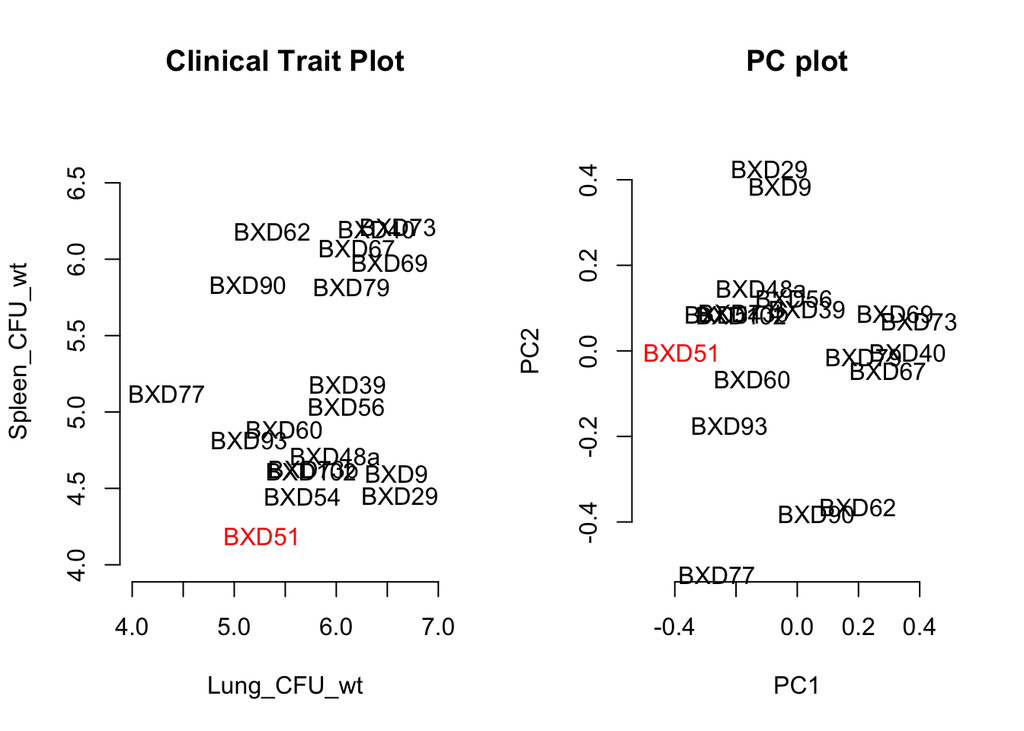

```r
par(xpd = TRUE, mfrow = c(1,2))
plot(pheno[,1:2], type = "n", axes = FALSE, xlim = c(4,7), ylim = c(4,6.8),
main = "Clinical Trait Plot")
strain.col <- rep("black", nrow(pheno))
strain.col[which(rownames(pheno) == "BXD51")] <- "red"
text(pheno[,1:2], labels = rownames(pheno), col = strain.col)
axis(1);axis(2)

clin.decomp <- plot.decomp(pheno[,1:2], plot.results = FALSE)
plot(clin.decomp$u[,1:2], type = "n", axes = FALSE, ylim = c(-0.5, 0.5),
xlim = c(-0.5, 0.5), xlab = "PC1", ylab = "PC2", main = "PC plot")
text(clin.decomp$u[,1:2], labels = rownames(pheno), col = strain.col)
axis(1);axis(2)
```

The strains have the following correlation matrix based on phenotype. BXD51 is a wicked outlier. Until we know more about that strain, I am removing it from the analysis.

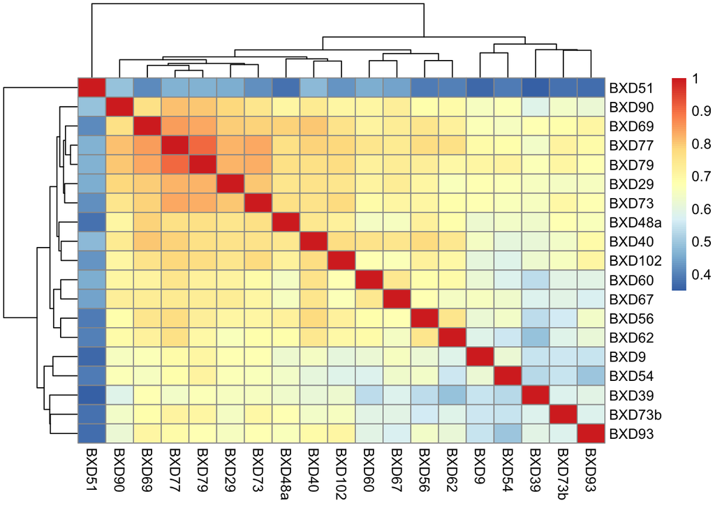

```r
pheno.cor <- cor(t(pheno))
pheatmap(pheno.cor)
```

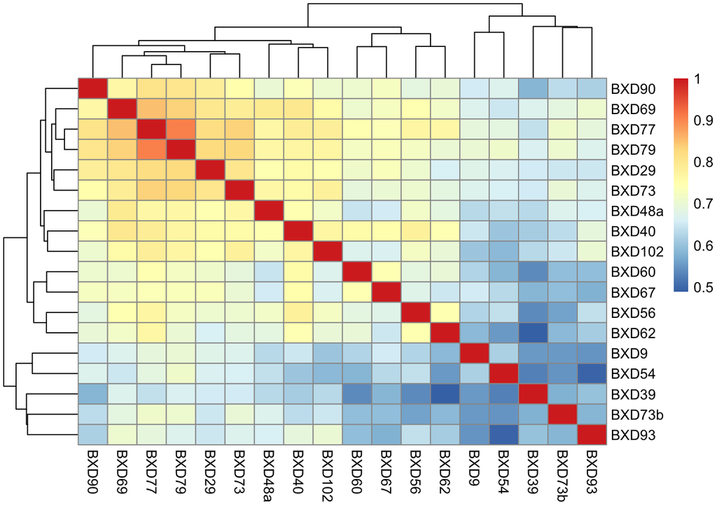

```r
if(remove.outlier){
  outlier.locale <- which(rownames(pheno) == "BXD51")
  if(length(outlier.locale) > 0){
    pheno <- pheno[-outlier.locale,]
  }
}
pheno.cor <- cor(t(pheno))
pheatmap(pheno.cor)
```

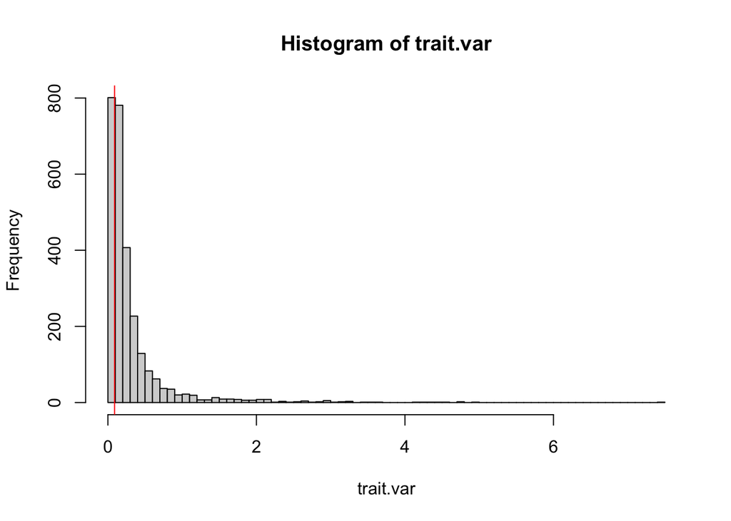

```r
trait.var <- apply(pheno, 2, var)
var.thresh = summary(trait.var)[2]
hist(trait.var, breaks = 100)
abline(v = var.thresh, col = "red")
```

```r
high.var <- which(trait.var > var.thresh)
if(high.var.pheno.only){
  var.pheno <- pheno[,high.var]
}else{
  var.pheno <- pheno
}
```

```r
if(scale.pheno){
  scaled.pheno <- apply(var.pheno, 2, scale)
  rownames(scaled.pheno) <- rownames(var.pheno)
}else{
  scaled.pheno <- var.pheno
}
```

The decomposition of the phenotype matrix is as follows.

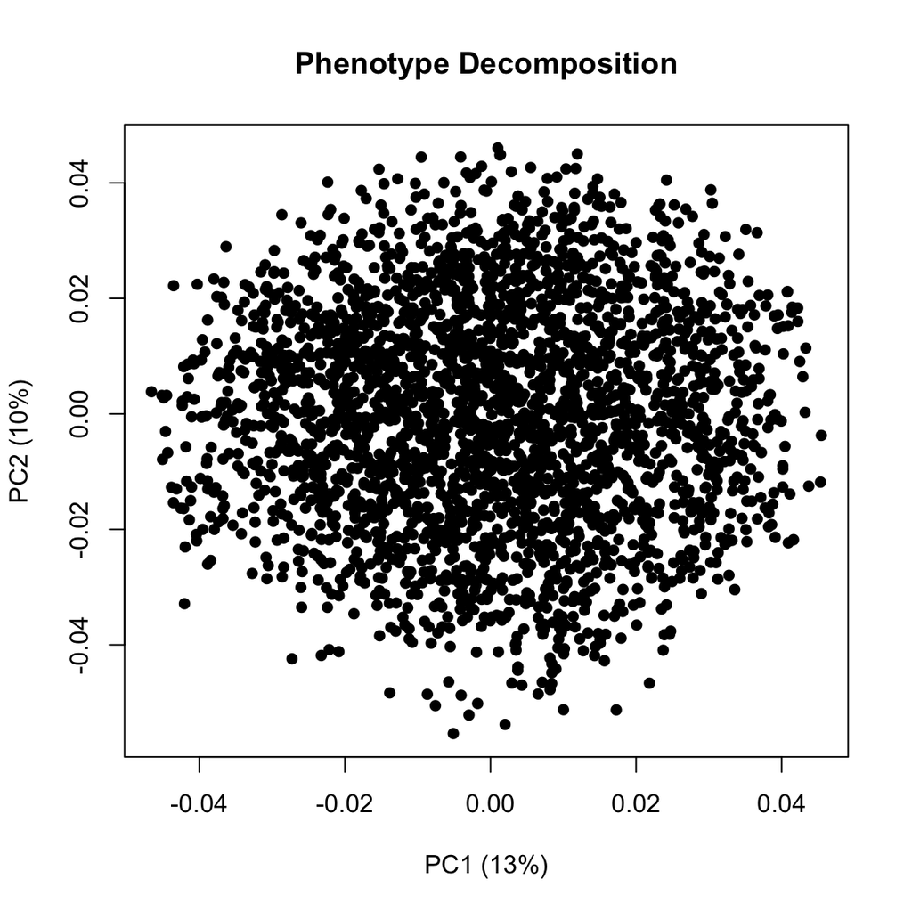

```r
pheno.decomp <- plot.decomp(t(scaled.pheno), plot.results = FALSE)
trait.var.exp <- pheno.decomp$d^2/sum(pheno.decomp$d^2)
plot(pheno.decomp$u[,1:2], main = "Phenotype Decomposition",
xlab = paste0("PC1 (", signif(trait.var.exp[1]*100, 2), "%)"),
ylab = paste0("PC2 (", signif(trait.var.exp[2]*100, 2), "%)"),
pch = 16)
```

```r
geno <- Reduce("cbind", lapply(geno.probs, function(x) x[,2,]))
if(remove.outlier){
  outlier.locale <- which(rownames(geno) == "BXD51")
  if(length(outlier.locale) > 0){
    geno <- geno[-outlier.locale,]
  }
}
```

## Construct CAPE object

```r
clin.pheno <- scaled.pheno[,1:2]
seq.pheno <- apply(scaled.pheno[,3:ncol(scaled.pheno)], 2, function(x) scale.between.vals(x, 0, 1))
continuous.geno <- abind(1-seq.pheno, seq.pheno, along = 3)
cont.geno <- aperm(continuous.geno, c(1,3,2))
colnames(cont.geno) <- c("A", "B")

if(include.genetic.markers){
  geno.array <- abind(1-geno, geno, along = 3)
  geno.perm <- aperm(geno.array, c(1,3,2))
  colnames(geno.perm) <- c("A", "B")
  full.geno <- abind(geno.perm, cont.geno, along = 3)
  geno.chromosome <- unlist(sapply(1:length(map), function(x) rep(names(map)[x], length(map[[x]]))))
  tn.chromosome <- rep(20, dim(cont.geno)[3])
  chromosome <- c(geno.chromosome, tn.chromosome)
  marker_num <- 1:dim(full.geno)[3]
  geno_location <- unlist(map)
  tn.location <- seq(length(geno_location) + 1, length(geno_location)+dim(cont.geno)[3], 1)
  marker_location <- c(geno_location, tn.location)
  ex.path <- here("results", "geno_TnSeq")
}else{
  full.geno <- cont.geno
  chromosome = rep(1, dim(full.geno)[3])
  marker_num <- 1:dim(full.geno)[3]
  marker_location <- 1:dim(full.geno)[3]
  ex.path <- here("results", "just_TnSeq")
}

names(dimnames(full.geno)) <- c("mouse", "allele", "locus")
data.obj <- list("pheno" = clin.pheno, "geno_names" = dimnames(full.geno),
"chromosome" = chromosome, "marker_num" = marker_num,
"marker_location" = marker_location)


#we used the original data set to create the
#cape object. Now we need to remove the outlier
#if it was removed above.
common.ind <- intersect(rownames(data.obj$pheno), rownames(pheno))
common.pheno.locale <- match(common.ind, rownames(full.geno))
data.obj$geno_names[[1]] <- data.obj$geno_names[[1]][common.pheno.locale]
data.obj$pheno <- data.obj$pheno[common.pheno.locale,]

cross.obj <- Cape$new(
parameter_file = file.path(ex.path, "cape.parameters.yml"),
results_path = ex.path,
pheno = data.obj$pheno,
chromosome = data.obj$chromosome,
marker_num = data.obj$marker_num,
marker_location = data.obj$marker_location,
geno_names = data.obj$geno_names,
geno = full.geno
)

final.cross <- run_cape(pheno_obj = cross.obj, geno_obj = full.geno, p_or_q = 0.05,
results_path = ex.path, param_file = file.path(ex.path, "cape.parameters.yml"))

write.data.for.shiny(final.cross, full.geno, name = basename(ex.path), path = ex.path)
```

```r
data.obj <- readRDS(file.path(ex.path, "cross.RData"))
geno.obj <- readRDS(file.path(ex.path, "cross_geno.RData"))
pairscan.obj <- readRDS(file.path(ex.path, "cross_pairscan.RData"))

plot.null.dist(data.obj, pairscan.obj, ex.path)
head(data.obj$var_to_var_p_val)
```

```
##      Source        Target          Effect              SE
## [1,] "RVBD0918_B"  "UNCHS019387_B" "-1.28590742862906" "0.0475906265071656"
## [2,] "RVBD2230c_B" "UNCHS019387_B" "-1.51658039918398" "0.0632074866883035"
## [3,] "RVBD0194_B"  "UNCHS019387_B" "-1.71944741061077" "0.101480229731752"
## [4,] "RVBD2793c_B" "UNCHS019387_B" "-1.81515495623299" "0.107933975819479"
## [5,] "RVBD3658c_B" "UNCHS019387_B" "-1.50763271588219" "0.0939536311133953"
## [6,] "RVBD3395A_B" "UNCHS019387_B" "-1.11120674604527" "0.0852243702342334"
##      |Effect|/SE        P_empirical            p_adjusted
## [1,] "27.0201828176278" "2.4856367480508e-05"  "0.999927907203719"
## [2,] "23.9936830056656" "2.98276409765874e-05" "0.999927907203719"
## [3,] "16.9436688816716" "5.51811358067145e-05" "0.999927907203719"
## [4,] "16.8172713221355" "5.71696452051906e-05" "0.999927907203719"
## [5,] "16.0465614582004" "6.01524093027939e-05" "0.999927907203719"
## [6,] "13.0386031952034" "0.000103402488718984" "0.999927907203719"
```

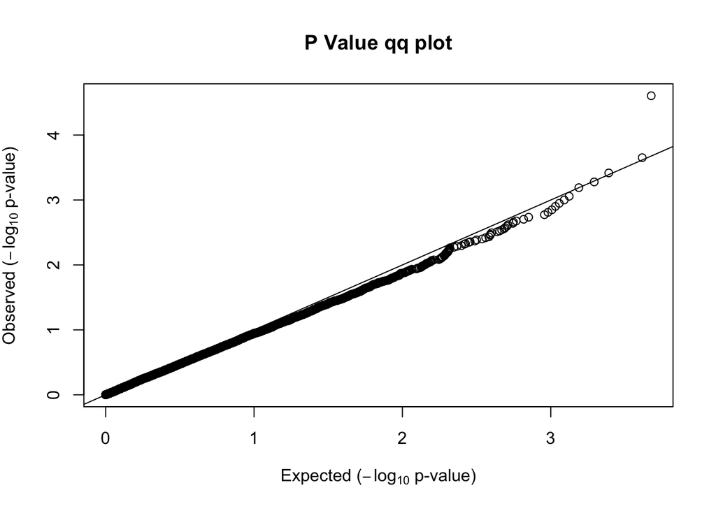

```r
qqunif.plot(as.numeric(data.obj$var_to_var_p_val[,"P_empirical"]))
```

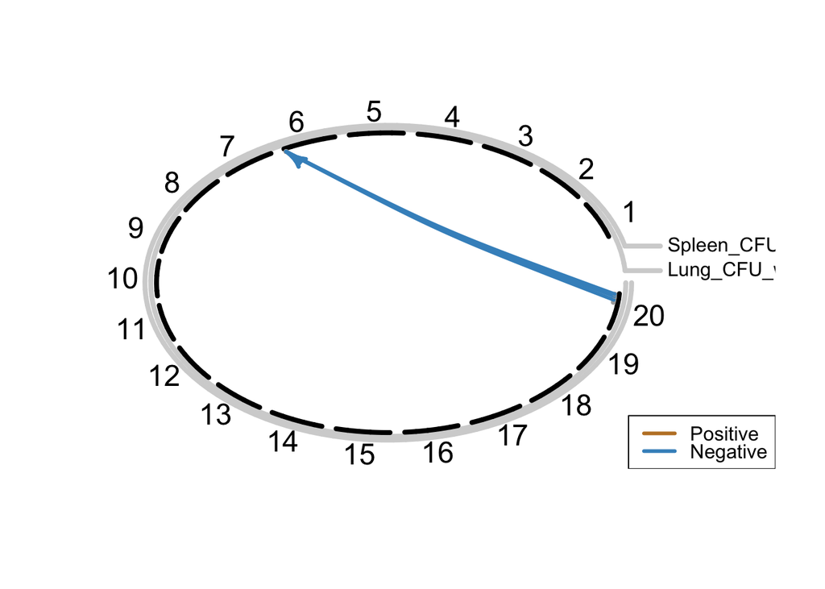

```r
pvals <- as.numeric(data.obj$var_to_var_p_val[,"P_empirical"])
adj.p <- p.adjust(pvals, "fdr")

data.obj <- calc_p(data.obj, "none")
p_or_q = 0.0001
data.obj <- get_network(data.obj, geno.obj, p_or_q)
plot_network(data.obj)
```

```r
var.inf <- write_variant_influences(data.obj, p_or_q = p_or_q, write_file = FALSE)
show.cols <- c(1,4,10, 13)
var.inf[,show.cols]
```

```
##      Source        Target          Effect              P_empirical
## [1,] "RVBD0918_B"  "UNCHS019387_B" "-1.28590742862906" "2.4856367480508e-05"
## [2,] "RVBD2230c_B" "UNCHS019387_B" "-1.51658039918398" "2.98276409765874e-05"
## [3,] "RVBD0194_B"  "UNCHS019387_B" "-1.71944741061077" "5.51811358067145e-05"
## [4,] "RVBD2793c_B" "UNCHS019387_B" "-1.81515495623299" "5.71696452051906e-05"
## [5,] "RVBD3658c_B" "UNCHS019387_B" "-1.50763271588219" "6.01524093027939e-05"
```

```r
for(idx in 1:nrow(var.inf)){
  marker1 <- var.inf[idx, "Source"]
  marker2 <- var.inf[idx, "Target"]
  #print(var.inf[idx,show.cols,drop=FALSE])

  fig.list <- plot_continuous_effects(data.obj, geno.obj, marker1, marker2,
  plot_type = "l", prob = 0.90, sig.dig = 3)
  fig.list[[1]][[2]] #phenotype 1 with Target on x axis
  fig.list[[2]][[2]] #phenotype 2 with Target on x axis

  surface.fig <- plot_continuous_effects(data.obj, geno.obj, marker1, marker2,
  plot_type = "h", sig.dig = 3, bins_marker1 = 10, bins_marker2 = 10,
  separate_windows = TRUE)
  surface.fig[[1]] #phenotype 1
  surface.fig[[2]] #phenotype 2
}
```